# adult_predict_income_flagship

```python
import pandas as pd
import numpy as np
import matplotlib.pyplot as plt
import seaborn as sns
sns.set()
```

```python
df = pd.read_csv("adult.data")
```

This dataset has demographic and financial details of individuals and the target is whether income is <=50K or > 50K (since units of income are not given, I assume it means income in $)

```python
df.head()
```

|  | age | workclass | fnlwgt | education | education-num | marital-status | occupation | relationship | race | sex | capital-gain | capital-loss | hours-per-week | native-country | Income |
| --- | --- | --- | --- | --- | --- | --- | --- | --- | --- | --- | --- | --- | --- | --- | --- |
| 0 | 39 | State-gov | 77516 | Bachelors | 13 | Never-married | Adm-clerical | Not-in-family | White | Male | 2174 | 0 | 40 | United-States | <=50K |
| 1 | 50 | Self-emp-not-inc | 83311 | Bachelors | 13 | Married-civ-spouse | Exec-managerial | Husband | White | Male | 0 | 0 | 13 | United-States | <=50K |
| 2 | 38 | Private | 215646 | HS-grad | 9 | Divorced | Handlers-cleaners | Not-in-family | White | Male | 0 | 0 | 40 | United-States | <=50K |
| 3 | 53 | Private | 234721 | 11th | 7 | Married-civ-spouse | Handlers-cleaners | Husband | Black | Male | 0 | 0 | 40 | United-States | <=50K |
| 4 | 28 | Private | 338409 | Bachelors | 13 | Married-civ-spouse | Prof-specialty | Wife | Black | Female | 0 | 0 | 40 | Cuba | <=50K |

```python
df.shape
```

```
(32561, 15)
```

```python
df['Income'].value_counts()/df.shape[0]
```

```
 <=50K    0.75919
 >50K     0.24081
Name: Income, dtype: float64
```

We have imbalanced classes. We will rank our models on the basis of f1-score, since we don't have any information about what is more important here - precision or recall

# Data Cleanup

Education and education-num are identical.  
Relationship takes care of marital-status.  
Native-country should not really matter. Besides, there are too many categories there to encode in any useful way.

```python
todrop = list(['education','native-country','marital-status'])
df = df.drop(todrop,axis=1)

#replacing ? in workclass with mode of column
df['workclass']=df['workclass'].replace(' ?',df['workclass'].mode()[0])

num_cols = df.select_dtypes(np.number).columns.tolist()
cat_cols = list(set(df.columns.tolist())-set(num_cols))
cat_cols.remove('Income')
```

# Plotting Numerical Columns (Histograms)

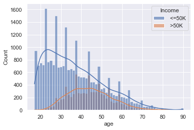

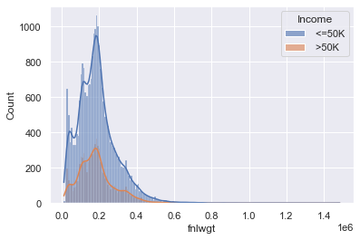

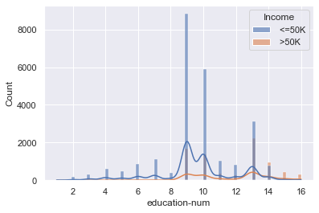

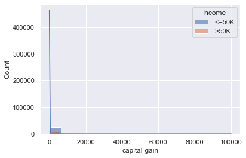

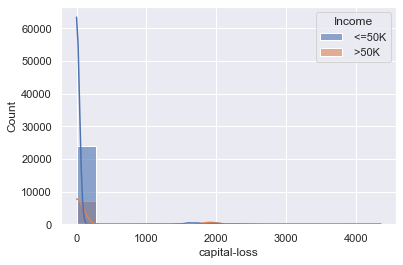

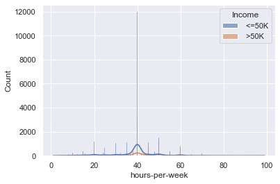

```python
for i in num_cols:
    sns.histplot(data=df,x=i,hue='Income',kde=True,alpha=0.6)
    plt.xlabel(i)
    plt.show()
```

# Plotting Categorical Columns

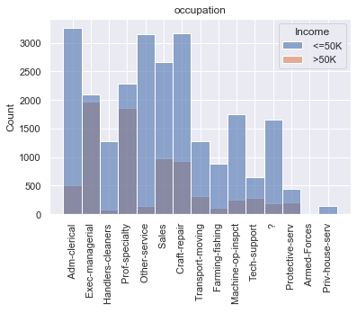

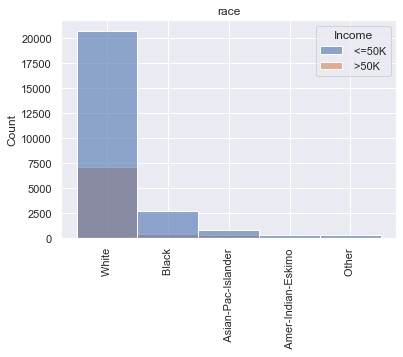

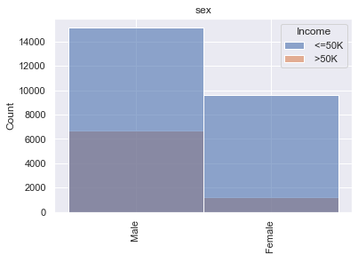

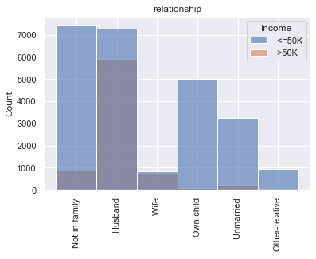

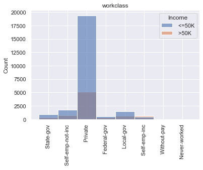

```python
for i in cat_cols:
    sns.histplot(data=df,x=i,hue='Income',alpha=0.6)
    plt.title(i)
    plt.xticks(rotation=90)
    plt.xlabel(None)
    plt.show()
```

### Let's simplify the categorical columns a bit

Workclass: Private or not private  
Race: white or not white (I know, super-racist. But the data reflects that whites have a higher proportion of people earning >50K.)  
Relationship: married, not-married  
Occupation: (Exec-manegerial, Prof-speciality) vs others. this takes care of the '?'s in occupation. These two professions have the highest proportion of people earning >50K

```python
def simplify_categories(df):
    workclass_pvt = df['workclass'].loc[df['workclass']==' Private'].index
    workclass_notpvt = df['workclass'].loc[df['workclass']!=' Private'].index
    df.loc[workclass_pvt,'workclass'] = 1
    df.loc[workclass_notpvt,'workclass'] = 0

    race_w = df['race'].loc[df['race']==' White'].index
    race_nw = df['race'].loc[df['race']!=' White'].index
    df.loc[race_w,'race']=0
    df.loc[race_nw,'race']=1

    rel_m = df['relationship'].loc[(df['relationship']==' Husband') | (df['relationship']==' Wife')].index #married
    rel_nm = df['relationship'].loc[(df['relationship']!=' Husband') & (df['relationship']!=' Wife')].index #not-married
    df.loc[rel_m,'relationship'] = 1
    df.loc[rel_nm,'relationship'] = 0

    df['sex'] = df['sex'].replace({' Male':0,' Female':1})

    occ_ep = df['occupation'].loc[(df['occupation']==' Exec-managerial') | (df['occupation']==' Prof-specialty')].index
    #exec-managerial or prof-specialty
    occ_nep = df['occupation'].loc[(df['occupation']!=' Exec-managerial') & (df['occupation']!=' Prof-specialty')].index
    #NOT (exec-managerial or prof-specialty)
    df.loc[occ_ep,'occupation'] = 1
    df.loc[occ_nep,'occupation'] = 0
    return df

df = simplify_categories(df)
df[cat_cols] = df[cat_cols].astype(int)
```

# Histogram of Modified Categorical Columns

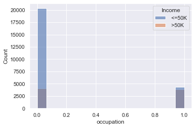

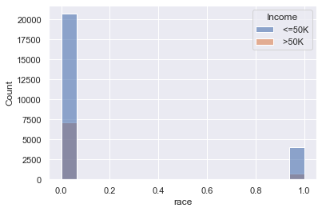

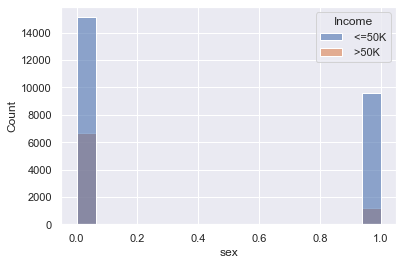

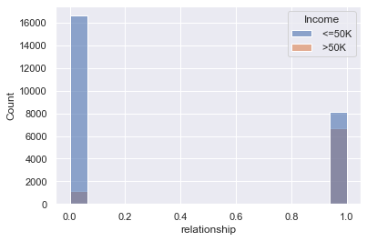

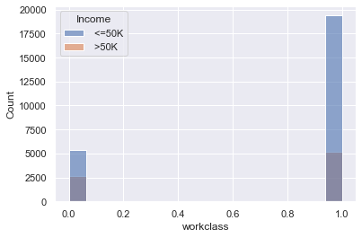

```python
for i in cat_cols:
    sns.histplot(data=df,x=i,hue='Income',alpha=0.6)
    plt.xlabel(i)
    plt.show()
```

# Heatmap of Correlation Matrix

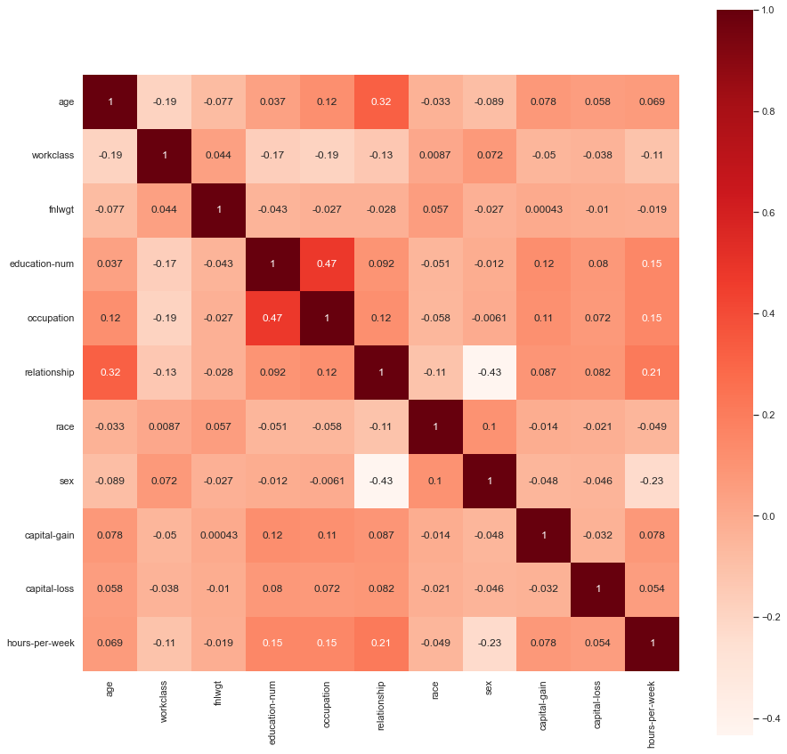

```python
corr = df.drop('Income',axis=1).corr()

fig, ax = plt.subplots(figsize=(15,15))
sns.heatmap(corr,annot=True,square=True,cmap='Reds',ax=ax)
plt.show()
```

# Processing the Data for Fitting

```python
from sklearn.preprocessing import MinMaxScaler, LabelEncoder
from sklearn.model_selection import train_test_split

trainX, testX, trainY, testY = train_test_split(df.drop('Income',axis=1),df['Income'],test_size=0.2,random_state=2)

scaler = MinMaxScaler()
scaler.fit(trainX)

X_train = scaler.transform(trainX)
X_test = scaler.transform(testX)

le = LabelEncoder()
le.fit(trainY)

y_train = le.transform(trainY)
y_test = le.transform(testY)
```

# Model Fitting

```python
from sklearn.linear_model import LogisticRegression, SGDClassifier
from sklearn.naive_bayes import GaussianNB
from sklearn.svm import SVC
from sklearn.tree import DecisionTreeClassifier
from sklearn.ensemble import RandomForestClassifier, AdaBoostClassifier, GradientBoostingClassifier
from catboost import CatBoostClassifier
from xgboost import XGBClassifier
from lightgbm import LGBMClassifier

from sklearn.metrics import f1_score, accuracy_score
```

```python
classifiers = [LogisticRegression(), GaussianNB(), SVC(), DecisionTreeClassifier(),
               RandomForestClassifier(),
               LGBMClassifier(), XGBClassifier(use_label_encoder=False), CatBoostClassifier(verbose=False)]

scores = pd.DataFrame(columns=['Classifier','Test_f1','Train_f1','TestAccuracy','TrainAccuracy'])

for i in classifiers:
    i.fit(X_train, y_train)
    y_pred_test = i.predict(X_test)
    y_pred_train = i.predict(X_train)
    scores.loc[len(scores.index)] = [i.__class__.__name__,
                                     f1_score(y_test,y_pred_test),f1_score(y_train,y_pred_train),
                                     accuracy_score(y_test,y_pred_test),accuracy_score(y_train,y_pred_train)]
```

```
[15:37:12] WARNING: C:\Windows\Temp\abs_557yfx631l\croots\recipe\xgboost-split_1659548953302\work\src\learner.cc:1115: Starting in XGBoost 1.3.0, the default evaluation metric used with the objective 'binary:logistic' was changed from 'error' to 'logloss'. Explicitly set eval_metric if you'd like to…
```

```python
scores.sort_values(by='Test_f1')
```

|  | Classifier | Test_f1 | Train_f1 | TestAccuracy | TrainAccuracy |
| --- | --- | --- | --- | --- | --- |
| 1 | GaussianNB | 0.546863 | 0.549687 | 0.820359 | 0.823249 |
| 3 | DecisionTreeClassifier | 0.601324 | 0.999440 | 0.805773 | 0.999731 |
| 2 | SVC | 0.611070 | 0.613488 | 0.840319 | 0.843558 |
| 0 | LogisticRegression | 0.624864 | 0.630015 | 0.841087 | 0.843174 |
| 4 | RandomForestClassifier | 0.653351 | 0.999440 | 0.842776 | 0.999731 |
| 6 | XGBClassifier | 0.675052 | 0.771802 | 0.857209 | 0.899340 |
| 7 | CatBoostClassifier | 0.679298 | 0.754714 | 0.859665 | 0.892621 |
| 5 | LGBMClassifier | 0.685413 | 0.739949 | 0.862583 | 0.886018 |

Performance isn't stellar wrt f1-score, but it isn't too bad. Let us look at the confusion matrix of the best model, the LGBMClassifier.

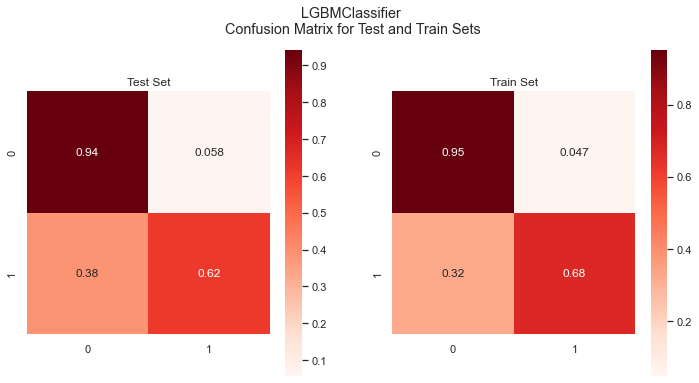

```python
from sklearn.metrics import confusion_matrix

y_pred_test = classifiers[5].predict(X_test)
y_pred_train = classifiers[5].predict(X_train)

cm_test = confusion_matrix(y_test,y_pred_test,normalize='true')
cm_train = confusion_matrix(y_train,y_pred_train,normalize='true')

fig, (ax1,ax2) = plt.subplots(1,2,figsize=(12,6))
fig.suptitle("LGBMClassifier\n Confusion Matrix for Test and Train Sets")
sns.heatmap(cm_test,cbar=True,annot=True,cmap='Reds',square=True,ax=ax1)
ax1.set_title("Test Set")
sns.heatmap(cm_train,cbar=True,annot=True,cmap='Reds',square=True,ax=ax2)
ax2.set_title("Train Set")
plt.show()
```

The confusion matrices are normalized along the rows, which means the diagonals represent the recall score wrt to that row. As expected, the minority class has poor recall score. We can over-sample the minority class and refit the model. That should give us a better result

# Over-sampling the Minority Class ( >50K) in the Training Set

```python
traindf = pd.concat([trainX,pd.DataFrame(trainY)],axis=1)

n0, n1 = traindf['Income'].value_counts()

class0 = traindf[traindf['Income']==' <=50K']
class1 = traindf[traindf['Income']==' >50K']
```

```python
print("Before Sampling: ")
print("Fraction of >50K (class 1): {}".format(n1/(n0+n1)))

class1over = class1.sample(int(2.5*n1),replace=True)
overdf = pd.concat([class0,class1over],axis=0).sample(frac=1)

print("After Sampling")
print("Fraction of >50K (class 1): {}".format(overdf['Income'].value_counts()[1]/overdf.shape[0]))
```

```
Before Sampling:
Fraction of >50K (class 1): 0.24017199017199017
After Sampling
Fraction of >50K (class 1): 0.44140889591329874
```

```python
X_train = scaler.transform(overdf.drop('Income',axis=1))
y_train = le.transform(overdf['Income'])
```

# Fitting Model to Data with Over-sampled Minority Class

We will only fit to the best 3 models: CatBoost, XGBoost and LGBM

```python
classifiers_over = [LGBMClassifier(),XGBClassifier(),CatBoostClassifier(verbose=False)]

scores_over = pd.DataFrame(columns=['Classifier','Test_f1','Train_f1','TestAccuracy','TrainAccuracy'])

for i in classifiers_over:
    i.fit(X_train, y_train)
    y_pred_test = i.predict(X_test)
    y_pred_train = i.predict(X_train)
    scores_over.loc[len(scores_over.index)] = [i.__class__.__name__,f1_score(y_test,y_pred_test),f1_score(y_train,y_pred_train),
                                               accuracy_score(y_test,y_pred_test),accuracy_score(y_train,y_pred_train)]
```

```
[15:43:13] WARNING: C:\Windows\Temp\abs_557yfx631l\croots\recipe\xgboost-split_1659548953302\work\src\learner.cc:1115: Starting in XGBoost 1.3.0, the default evaluation metric used with the objective 'binary:logistic' was changed from 'error' to 'logloss'. Explicitly set eval_metric if you'd like to…
```

```python
scores_over.sort_values(by='Test_f1')
```

|  | Classifier | Test_f1 | Train_f1 | TestAccuracy | TrainAccuracy |
| --- | --- | --- | --- | --- | --- |
| 1 | XGBClassifier | 0.699860 | 0.882722 | 0.835253 | 0.893486 |
| 0 | LGBMClassifier | 0.701602 | 0.848449 | 0.831261 | 0.862384 |
| 2 | CatBoostClassifier | 0.703260 | 0.869386 | 0.836481 | 0.881886 |

# Confusion Matrices (Test Set) - Before and After Over-sampling

The confusion matrices are normalized along the rows, which means the diagonals represent the recall score wrt to that row.

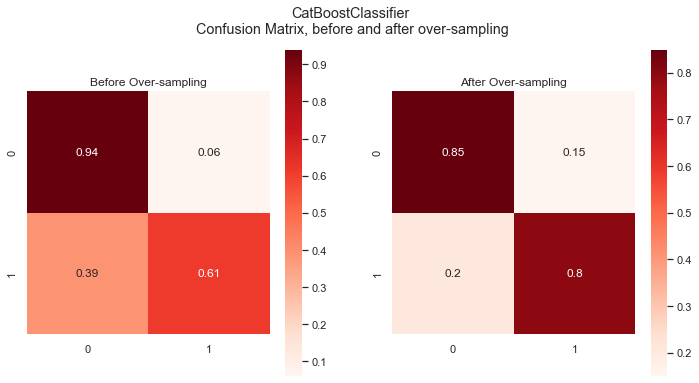

```python
#CatBoost Before and after

#Before:
y_pred_test = classifiers[7].predict(X_test)
cm_before = confusion_matrix(y_test,y_pred_test,normalize='true')

#After:
y_pred_test = classifiers_over[2].predict(X_test)
cm_after = confusion_matrix(y_test,y_pred_test,normalize='true')

fig, (ax1,ax2) = plt.subplots(1,2,figsize=(12,6))
fig.suptitle("CatBoostClassifier\n Confusion Matrix, before and after over-sampling")
sns.heatmap(cm_before,cbar=True,annot=True,cmap='Reds',square=True,ax=ax1)
ax1.set_title("Before Over-sampling")
sns.heatmap(cm_after,cbar=True,annot=True,cmap='Reds',square=True,ax=ax2)
ax2.set_title("After Over-sampling")
plt.show()
```

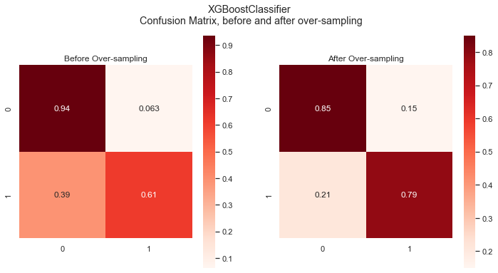

```python
#XGBoost Before and after

#Before:
y_pred_test = classifiers[6].predict(X_test)
cm_before = confusion_matrix(y_test,y_pred_test,normalize='true')

#After:
y_pred_test = classifiers_over[1].predict(X_test)
cm_after = confusion_matrix(y_test,y_pred_test,normalize='true')

fig, (ax1,ax2) = plt.subplots(1,2,figsize=(12,6))
fig.suptitle("XGBoostClassifier\n Confusion Matrix, before and after over-sampling")
sns.heatmap(cm_before,cbar=True,annot=True,cmap='Reds',square=True,ax=ax1)
ax1.set_title("Before Over-sampling")
sns.heatmap(cm_after,cbar=True,annot=True,cmap='Reds',square=True,ax=ax2)
ax2.set_title("After Over-sampling")
plt.show()
```

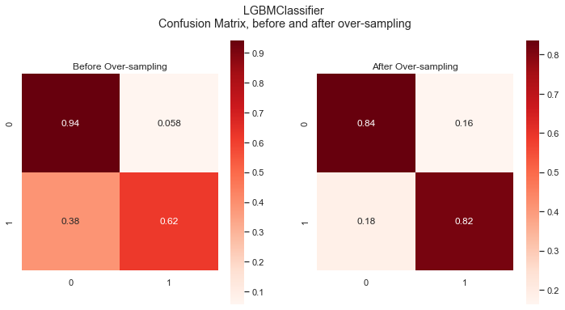

```python
#LGBM Before and after

#Before:
y_pred_test = classifiers[5].predict(X_test)
cm_before = confusion_matrix(y_test,y_pred_test,normalize='true')

#After:
y_pred_test = classifiers_over[0].predict(X_test)
cm_after = confusion_matrix(y_test,y_pred_test,normalize='true')

fig, (ax1,ax2) = plt.subplots(1,2,figsize=(12,6))
fig.suptitle("LGBMClassifier\n Confusion Matrix, before and after over-sampling")
sns.heatmap(cm_before,cbar=True,annot=True,cmap='Reds',square=True,ax=ax1)
ax1.set_title("Before Over-sampling")
sns.heatmap(cm_after,cbar=True,annot=True,cmap='Reds',square=True,ax=ax2)
ax2.set_title("After Over-sampling")
plt.show()
```

In all three classifiers, we see an improvement in recall score wrt to class 1 (the minority class), but as expected, it comes at an expense of recall wrt class 0 (majority class)